# Clustering

2023-12-09

## Clustering

# Hierarchical clustering

Hierarchical clustering methods can be classified as agglomerative (a.k.a., bottom-up) or divisive (a.k.a., top-down) and by the linkage method - how clusters are merged or divided - and distance metrics used. The difference between agglomerative and divisive clustering methods is that the former starts by considering each data point as an individual cluster and merges them successively based on their similarity. At each step, the most similar clusters are merged until all points belong to one cluster. On the opposite end, the divisive approach begins with all data points in a single cluster and recursively splits this cluster into smaller ones based on dissimilarity until each data point is in its cluster.

Regarding distance metrics, the euclidean approach consists of measuring the straight-line distance between two data points in a multidimensional space; while correlation-based distances measure the similarity between two variables by assessing how they change concerning each other. Commonly used correlation-based distances include Pearson and Spearman correlation. Both of them estimate the how strongly and in which direction two variables are related. However, Pearson correlation evaluates linear relationships and assumes a normal distribution, while Spearman correlation assesses monotonic relationships, providing an alternative when dealing with data that may not satisfy the assumptions of linearity or normality required by Pearson correlation (Winter, Gosling & Potter, 2016). Both have been indicated to render similar results if the data is (near) normally distributed. Since this assumption can be made for this dataset, the correlation method here used is Pearson’s.

Linkage methods include single, average and complete linkage, among others. Single linkage determines the distance between two clusters based on the shortest distance between any member of one cluster and any member of the other cluster, average linkage computes the distance between clusters based on the average distance between all pairs of points in them and complete linkage measures the distance between clusters based on the maximum distance between any member of one cluster and any member of the other cluster. A problem with single linkage is the chaining effect, where long, trailing clusters or chains are formed because, looking for the shortest distance, the algorithm becomes sensitive to noise and outliers and connects clusters that should not be connected. On the opposite end, complete linkage can break up bigger clusters. In this context, average linkage can provide a compromise between the two while remaining robust (Grigorev, 2015).

To mitigate the chaining effect, other linkage methods like complete linkage (maximum linkage) or average linkage are often used. These methods tend to be less susceptible to noise and outliers and can produce more balanced, spherical clusters compared to single linkage. However, the choice of linkage method should consider the specific characteristics of the dataset and the desired properties of the resulting clusters.

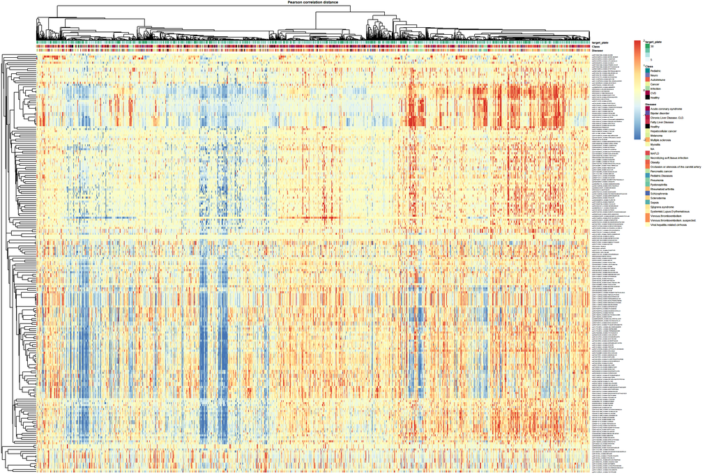

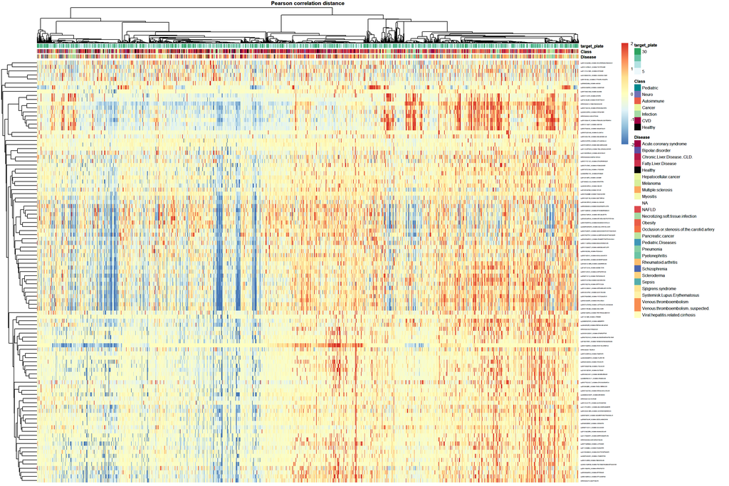

# References

De Winter, J. C., Gosling, S. D., & Potter, J. (2016). Comparing the Pearson and Spearman correlation coefficients across distributions and sample sizes: A tutorial using simulations and empirical data. *Psychological methods, 21*(3), 273.

Grigorev, A. (2015, June 5). *Agglomerative clustering*. ML wiki. http://mlwiki.org/index.php/Agglomerative_Clustering